# Analysis on the Relations between Subjective Class and Objective family Income Status

Han-Wool Jeong

2014.10.21

### Introduction:

This analysis is to verify if subjective class identification represents objective class status correctly by using “General Social Survey Cumulative File, 1972-2012 Coursera Extract.” My hyperthesis is that there is a difference between the average of respondent’s family income from self reported classes.

To compare means of 3+ groups, I use a test called analsys of variance(ANOVA) and F statisic.

H0: M1 =M2 = … Mk HA: At least one pair of means are different from each other.

### Data:

1. Description
- variable y <- gss$coninc (numeric variable)

```r
summary(gss$coninc)
```

```
##    Min. 1st Qu.  Median    Mean 3rd Qu.    Max.    NA's
##     383   18400   35600   44500   59500  180000    5829
```

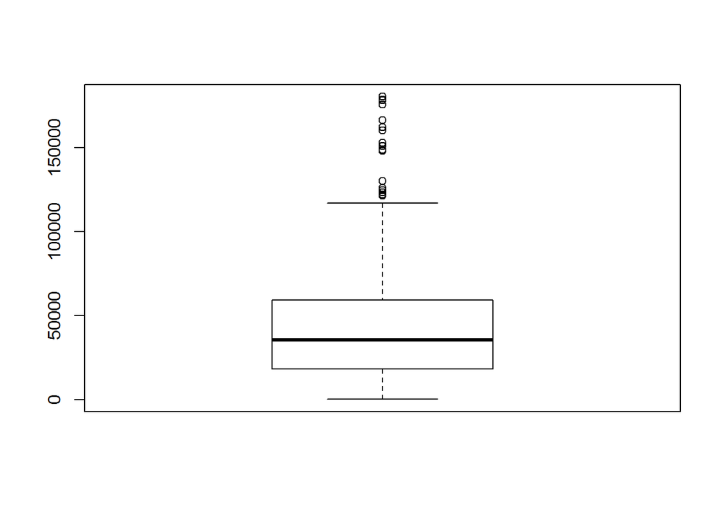

```r
boxplot(gss$coninc)
```

- variable x <- gss$class

```r
table(gss$class)
```

```
##
##   Lower Class Working Class  Middle Class   Upper Class      No Class
##          3147         24458         24289          1741             1
```

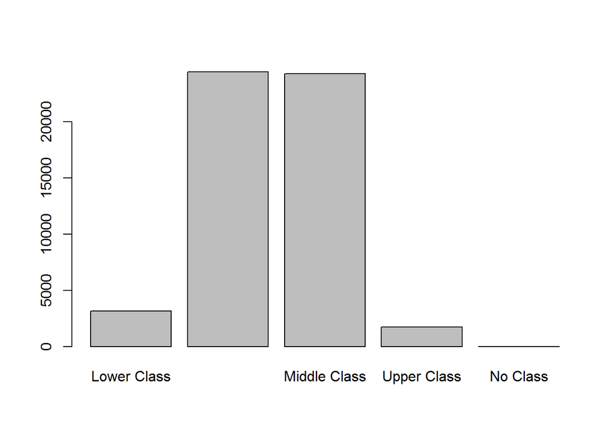

```r
barplot(table(gss$class))
```

### Exploratory data analysis:

-Data Cleaning

```r
y <- gss$coninc
x <- gss$class
x_clean <- x[x != "No Class"] # excluding "No Class"
droplevels(x_clean)
```

[output not shown]

[output cut: 14251 more lines]

- loading inference # function

```r
source("http://bit.ly/dasi_inference")
```

- ANOVA Test

```r
inference(y, x_clean, est="mean", type="ht",alternative="greater", method="theoretical")
```

```
## Response variable: numerical, Explanatory variable: categorical
## ANOVA
## Summary statistics:
## n_Lower Class = 2811, mean_Lower Class = 32970, sd_Lower Class = 31863
## n_Working Class = 22069, mean_Working Class = 39829, sd_Working Class = 31964
## n_Middle Class = 21785, mean_Middle Class = 49437, sd_Middle Class = 37979
## n_Upper Class = 1549, mean_Upper Class = 60852, sd_Upper Class = 46179
## n_No Class = NA, mean_No Class = NA, sd_No Class = NA
```

```
## H_0: All means are equal.
## H_A: At least one mean is different.
## Analysis of Variance Table
##
## Response: y
##              Df   Sum Sq  Mean Sq F value Pr(>F)
## x             3 1.80e+12 6.00e+11     481 <2e-16
## Residuals 48210 6.01e+13 1.25e+09
##
## Pairwise tests: t tests with pooled SD
##               Lower Class Working Class Middle Class
## Working Class           0            NA           NA
## Middle Class            0             0           NA
## Upper Class             0             0            0
```

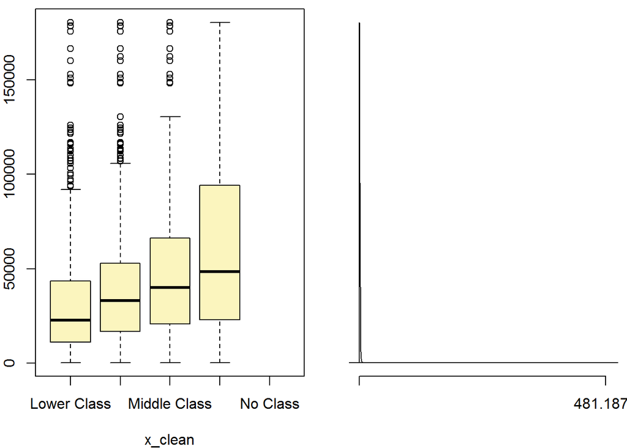

### Inference:

- p-value is the probability of at least as large a ratio between the “between” and “within” group variabilities if in fact the means of all groups are equal.
- According to the results from ANOVA test, p-value is very small and less than alpa, reject Ho.
- The Data provides convincing evidence that at least one pair of population means of family income are different from selp reported class